# Lecture 6：購買履歴と個人の需要

計量経済学II

Kei Ikegami

## 今日の問い

- 市場の平均的な需要から、一人の次の選択をどう予測するか。
- 同じ離散選択モデルに、その人の履歴を加える。
- 履歴が短いとき、集団の情報は何に役立つか。

## 前回まで

第4回：好みの分布を推定し、市場全体の代替関係と合併後の価格を計算した。

第5回：ゲスト講義。

今回：同じ分布を、個人の購買履歴に応じて更新する。

## まずQuiz 6

問題を開く

## 市場と個人で平均する分布が変わる

$$s_j=\int P_j(\theta)dF(\theta)$$

$$P_{ij}^{\mathrm{history}}=\int P_j(\theta)dF(\theta\mid H_i)$$

履歴を説明しやすい好みに、大きな重みを付ける。

## 企業のデータで必要なもの

- 誰が、いつ、何を選んだか。
- そのとき提示されていた選択肢と価格。
- 買わないという選択も含む機会。

購入した行だけでは、購入機会に対する確率をそのまま推定できない。

## コーヒーの選択

Aはブラック、Bは甘いコーヒー。価格は100円単位。

$$v_{iAt}=1.5-\theta_i-p_{iAt},\quad v_{iBt}=1.5+\theta_i-p_{iBt}$$

$$\theta_i\in\{-1.5,0,1.5\},\quad \pi=(.25,.5,.25)$$

outsideの効用は一時的ショックのみ。

## 簡略化している部分

- タイプの位置、定数、価格係数は既知。
- 母集団のタイプ割合を推定する。
- 価格は外生的。同じ人のタイプは固定。

価格内生性や習慣形成を同時に扱う例ではない。

## 同じ価格でも選択が違う

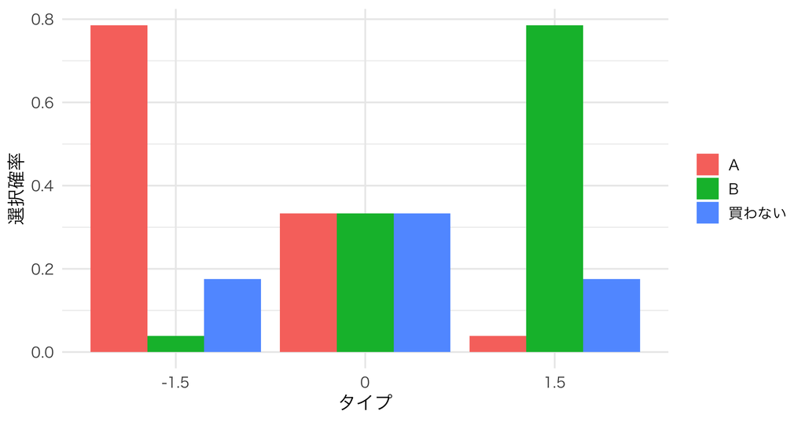

## 同じ選好が複数の選択を生む

$$L_i(\theta_k)=\prod_{t=1}^{T_i}P_{iy_{it}t}(\theta_k)$$

まずタイプを固定して各回の確率を掛ける。

$$L_i(\pi)=\sum_k\pi_k L_i(\theta_k)$$

その後に、タイプについて平均する。

## 平均と積の順序

$$\sum_k\pi_k\prod_tP_{iy_{it}t}(\theta_k)
\ne\prod_t\sum_k\pi_kP_{iy_{it}t}(\theta_k)$$

右辺では、各回でタイプを引き直すことになる。

## 母集団の割合を推定する

$$\hat\pi=\arg\max_\pi\sum_i\log L_i(\pi)$$

400人の最初の4回だけを使用する。

| type | truth | estimate |
| --- | --- | --- |
| -1.5 | 0.25 | 0.269 |
| 0.0 | 0.50 | 0.479 |
| 1.5 | 0.25 | 0.252 |

## 履歴を見た後の重み

$$w_{ik}=\frac{\hat\pi_kL_i(\theta_k)}{\sum_l\hat\pi_lL_i(\theta_l)}$$

母集団で多いタイプと、その人の履歴を説明しやすいタイプの両方に重みが付く。

## 一人の例

| id | occasion | pA | pB | y |
| --- | --- | --- | --- | --- |
| 1 | 1 | 1.421101 | 1.705005 | 2 |
| 1 | 2 | 1.776243 | 2.225994 | 0 |
| 1 | 3 | 1.928818 | 2.450031 | 2 |
| 1 | 4 | 1.025585 | 1.609222 | 2 |

| type | population | history |
| --- | --- | --- |
| -1.5 | 0.269 | 0.000 |
| 0.0 | 0.479 | 0.103 |
| 1.5 | 0.252 | 0.897 |

## 一人ずつ推定すると

本人の4回の選択だけで $\theta_i$ を最尤推定する。

同じ商品ばかりを選んだ人では、係数を極端にするほど当てはまりがよくなりやすい。

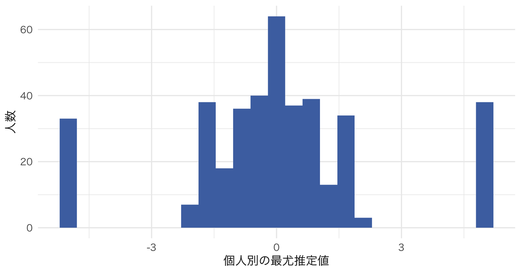

## 予測の方法を比べる

1. 母集団の割合のみ。
2. 個人別の最尤推定値。
3. 履歴で更新したタイプの重み。

同じ顧客の、推定に使わない20回で評価する。

## log loss

$$-\frac1{NT_{\rm test}}\sum_i\sum_t\log\hat P_{iy_{it}t}$$

実際に選ばれた選択肢に高い確率を付けるほど小さくなる。

学習用の当てはまりだけでは比較しない。

## 4回の履歴から予測

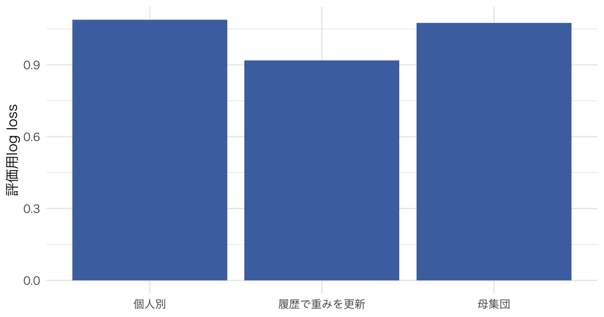

## 結果をどう読むか

短い履歴では、個人別推定の極端な係数が予測を悪くする。

母集団の情報と本人の履歴を合わせることで改善した。

これはタイプ分布の指定が妥当な今回の設定での結果である。

## 推定誤差も残る

$\hat\pi$ は400人の標本から推定した値。

顧客単位で履歴全体を復元抽出し、推定を繰り返す。

選択行をばらばらに抽出すると、個人内の依存を壊してしまう。

## 実証研究との接続

Rossi, McCulloch, and Allenby (1996) は、購買履歴を使ったクーポン配布を分析した。

短い履歴を使う配布の純便益は、一律配布の約2.5倍だった。これはその研究の市場・施策での結果である。

出典：[Marketing Science](https://pubsonline.informs.org/doi/10.1287/mksc.15.4.321)

## 履歴の予測と施策の効果

「この人は買いそうだ」と「この人へ送ると購入が増える」は異なる。

施策の比較には、送らなかった場合の行動が必要になる。第10回で扱う。

## 固定的な好みと状態依存

同じ商品を繰り返し買う理由は、もともとの好みかもしれない。

過去に買ったこと自体が次の選択を変える場合もある。

今回は前者のみ。後者との区別は第14回で扱う。

## まとめと次回

- 同じ個人係数が履歴全体に入る。
- 履歴を使ってタイプの重みを更新する。
- 短い履歴では集団の情報が役立つ。
- 予測は別の選択で評価する。

次回は好みを測る選択課題を設計するコンジョイント分析。

講義ノート / 課題6 / Playground